# problem set 1

Chandler James

October 9, 2019

# Part 1

```r
# load the data

pres_polls_2016 <- read_dta("~/Box Sync/SOC/data/pres_polls_2016.dta")
```

### 1

```r
# generate a variable, dem_pollshare, measuring the two party share of support for the Democrats based on the variables adjpoll_clinton and adjpoll_trump

pres_polls_2016 <- pres_polls_2016 %>%
  mutate(dem_pollshare = adjpoll_clinton/(adjpoll_clinton + adjpoll_trump))
```

### 2

```r
# generate a variable, demvoteshare, measuring the Democratic Party’s share of thetwo-party vote based on the variables DemVotes and RepVotes.

pres_polls_2016 <- pres_polls_2016 %>%
  mutate(demvoteshare = DemVotes/(DemVotes + RepVotes))
```

### 3

```r
# generate a variable, pollsminusvotes, measuring the difference between the two vari-ables (dempollshare minus demvoteshare)

pres_polls_2016 <- pres_polls_2016 %>%
  mutate(pollsminusvotes = dem_pollshare-demvoteshare)
```

### 4

```r
# generate a variable, abspollsminusvotes, measuring the absolute value of the differ-ence between the two variables (dempollshare minus demvoteshare).

pres_polls_2016 <- pres_polls_2016 %>%
  mutate(abspollsminusvotes = abs(dem_pollshare - demvoteshare))
```

# Part 2

### 1

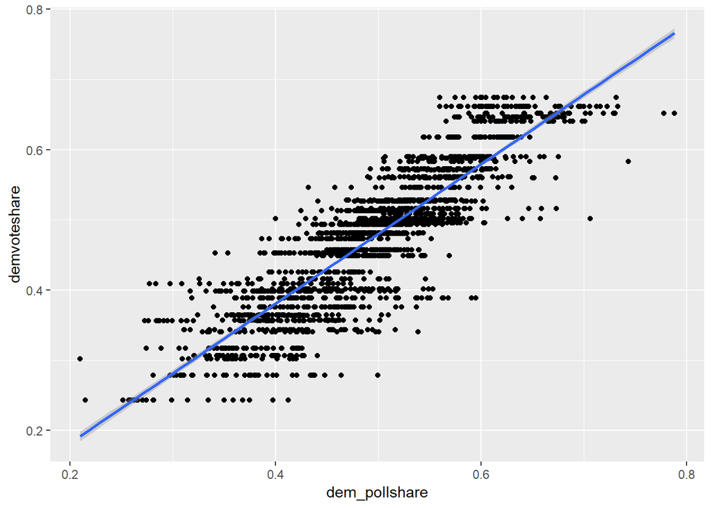

```r
# Make a scatter plot with dempollshare on the x-axis and demvoteshare on the y-axis.

pres_polls_2016 %>%
  ggplot(aes(dem_pollshare, demvoteshare)) +
  geom_point() +
  geom_smooth(method = "lm")
```

### 2

The graph above shows considerable correspondence between the x-axis (dem_pollshare) and y-axis (dem_voteshare). That is to say that the independent variable predicts the dependent variable. The slope of the line is near 45 degrees indicating that x predicts y reasonably well.

# Part 3

```r
summary(pres_polls_2016)
```

```
##      cycle         branch            matchup             state
##  Min.   :2016   Length:2330        Length:2330        Length:2330
##  1st Qu.:2016   Class :character   Class :character   Class :character
##  Median :2016   Mode  :character   Mode  :character   Mode  :character
##  Mean   :2016
##  3rd Qu.:2016
##  Max.   :2016
##
##    startdate             enddate             pollster
##  Min.   :2015-11-06   Min.   :2015-11-08   Length:2330
##  1st Qu.:2016-08-17   1st Qu.:2016-08-29   Class :character
##  Median :2016-09-16   Median :2016-09-26   Mode  :character
##  Mean   :2016-09-02   Mean   :2016-09-09
##  3rd Qu.:2016-10-14   3rd Qu.:2016-10-20
##  Max.   :2016-10-30   Max.   :2016-10-31
##
##     grade             samplesize      population        rawpoll_clinton
##  Length:2330        Min.   :  35.0   Length:2330        Min.   :11.04
##  Class :character   1st Qu.: 369.0   Class :character   1st Qu.:35.53
##  Mode  :character   Median : 568.0   Mode  :character   Median :41.77
##                     Mean   : 668.1                      Mean   :40.59
##                     3rd Qu.: 822.0                      3rd Qu.:46.00
##                     Max.   :7769.0                      Max.   :65.93
##                     NA's   :1
##  rawpoll_trump   rawpoll_johnson  rawpoll_mcmullin adjpoll_clinton
##  Min.   : 9.46   Min.   : 0.000   Min.   : 9.00    Min.   :16.63
##  1st Qu.:33.56   1st Qu.: 5.970   1st Qu.:20.00    1st Qu.:37.78
##  Median :39.55   Median : 7.545   Median :26.00    Median :42.96
##  Mean   :39.32   Mean   : 7.870   Mean   :23.24    Mean   :42.25
##  3rd Qu.:44.88   3rd Qu.: 9.500   3rd Qu.:29.00    3rd Qu.:46.74
##  Max.   :68.00   Max.   :25.000   Max.   :31.00    Max.   :71.10
##                  NA's   :704      NA's   :2313
##  adjpoll_trump   adjpoll_johnson  adjpoll_mcmullin     url
##  Min.   :19.13   Min.   :-3.372   Min.   :13.97    Length:2330
##  1st Qu.:37.48   1st Qu.: 3.265   1st Qu.:21.41    Class :character
##  Median :42.60   Median : 4.628   Median :26.09    Mode  :character
##  Mean   :42.60   Mean   : 4.988   Mean   :24.85
##  3rd Qu.:47.27   3rd Qu.: 6.279   3rd Qu.:29.66
##  Max.   :71.56   Max.   :19.278   Max.   :31.94
##                  NA's   :704      NA's   :2313
##     poll_id         DemVotes          RepVotes         quality_a
##  Min.   :35362   Min.   :  55973   Min.   :  95369   Min.   :0.000
##  1st Qu.:45407   1st Qu.: 420375   1st Qu.: 515231   1st Qu.:0.000
##  Median :46249   Median :1161167   Median :1221747   Median :0.000
##  Mean   :45914   Mean   :1651549   Mean   :1585889   Mean   :0.303
##  3rd Qu.:47200   3rd Qu.:2189316   3rd Qu.:2279543   3rd Qu.:1.000
##  Max.   :48000   Max.   :8753788   Max.   :4685047   Max.   :1.000
##
##  dem_pollshare     demvoteshare    pollsminusvotes     abspollsminusvotes
##  Min.   :0.2094   Min.   :0.2429   Min.   :-0.131719   Min.   :1.000e-08
##  1st Qu.:0.4483   1st Qu.:0.4018   1st Qu.:-0.007557   1st Qu.:1.349e-02
##  Median :0.5041   Median :0.4938   Median : 0.017480   Median :2.919e-02
##  Mean   :0.4979   Mean   :0.4781   Mean   : 0.019731   Mean   :3.793e-02
##  3rd Qu.:0.5465   3rd Qu.:0.5283   3rd Qu.: 0.044522   3rd Qu.:5.227e-02
##  Max.   :0.7880   Max.   :0.6744   Max.   : 0.221207   Max.   :2.212e-01
##
```

### 1

around 30.3% of the polls are considered to be top quality.

```r
# filtering for the top quality polls
top_pres_polls_2016 <- pres_polls_2016 %>%
  filter(quality_a == 1)
summary(top_pres_polls_2016)
```

```
##      cycle         branch            matchup             state
##  Min.   :2016   Length:706         Length:706         Length:706
##  1st Qu.:2016   Class :character   Class :character   Class :character
##  Median :2016   Mode  :character   Mode  :character   Mode  :character
##  Mean   :2016
##  3rd Qu.:2016
##  Max.   :2016
##
##    startdate             enddate             pollster
##  Min.   :2015-11-11   Min.   :2015-11-15   Length:706
##  1st Qu.:2016-08-12   1st Qu.:2016-08-25   Class :character
##  Median :2016-09-07   Median :2016-09-18   Mode  :character
##  Mean   :2016-08-23   Mean   :2016-09-04
##  3rd Qu.:2016-09-30   3rd Qu.:2016-10-12
##  Max.   :2016-10-28   Max.   :2016-10-31
##
##     grade             samplesize      population        rawpoll_clinton
##  Length:706         Min.   : 100.0   Length:706         Min.   :26.46
##  Class :character   1st Qu.: 340.2   Class :character   1st Qu.:38.35
##  Mode  :character   Median : 458.5   Mode  :character   Median :43.17
##                     Mean   : 544.6                      Mean   :43.32
##                     3rd Qu.: 678.0                      3rd Qu.:47.58
##                     Max.   :2606.0                      Max.   :65.89
##
##  rawpoll_trump   rawpoll_johnson  rawpoll_mcmullin adjpoll_clinton
##  Min.   :21.29   Min.   : 1.000   Min.   :20       Min.   :25.86
##  1st Qu.:36.00   1st Qu.: 6.000   1st Qu.:20       1st Qu.:38.08
##  Median :42.00   Median : 8.000   Median :20       Median :42.98
##  Mean   :41.70   Mean   : 7.831   Mean   :20       Mean   :42.79
##  3rd Qu.:47.64   3rd Qu.: 9.000   3rd Qu.:20       3rd Qu.:46.99
##  Max.   :60.20   Max.   :24.000   Max.   :20       Max.   :64.55
##                  NA's   :534      NA's   :705
##  adjpoll_trump   adjpoll_johnson   adjpoll_mcmullin     url
##  Min.   :21.40   Min.   :-0.4184   Min.   :21.6     Length:706
##  1st Qu.:37.77   1st Qu.: 3.0794   1st Qu.:21.6     Class :character
##  Median :42.99   Median : 4.4727   Median :21.6     Mode  :character
##  Mean   :42.78   Mean   : 4.8310   Mean   :21.6
##  3rd Qu.:48.09   3rd Qu.: 6.1726   3rd Qu.:21.6
##  Max.   :60.75   Max.   :19.2778   Max.   :21.6
##                  NA's   :534       NA's   :705
##     poll_id         DemVotes          RepVotes         quality_a
##  Min.   :35382   Min.   :  93758   Min.   :  95369   Min.   :1
##  1st Qu.:45013   1st Qu.: 539260   1st Qu.: 700714   1st Qu.:1
##  Median :45908   Median :1367716   Median :1322951   Median :1
##  Mean   :45564   Mean   :1847287   Mean   :1705340   Mean   :1
##  3rd Qu.:46796   3rd Qu.:2268839   3rd Qu.:2362631   3rd Qu.:1
##  Max.   :47996   Max.   :8753788   Max.   :4685047   Max.   :1
##
##  dem_pollshare     demvoteshare    pollsminusvotes    abspollsminusvotes
##  Min.   :0.3061   Min.   :0.2784   Min.   :-0.11467   Min.   :0.0001169
##  1st Qu.:0.4421   1st Qu.:0.4091   1st Qu.:-0.00858   1st Qu.:0.0128106
##  Median :0.5025   Median :0.4938   Median : 0.01665   Median :0.0272936
##  Mean   :0.5001   Mean   :0.4836   Mean   : 0.01647   Mean   :0.0333486
##  3rd Qu.:0.5480   3rd Qu.:0.5283   3rd Qu.: 0.03852   3rd Qu.:0.0458070
##  Max.   :0.7330   Max.   :0.6613   Max.   : 0.16919   Max.   :0.1691923
##
```

```r
# filtering for the low quality polls

low_pres_polls_2016 <- pres_polls_2016 %>%
  filter(quality_a == 0)
summary(low_pres_polls_2016)
```

```
##      cycle         branch            matchup             state
##  Min.   :2016   Length:1624        Length:1624        Length:1624
##  1st Qu.:2016   Class :character   Class :character   Class :character
##  Median :2016   Mode  :character   Mode  :character   Mode  :character
##  Mean   :2016
##  3rd Qu.:2016
##  Max.   :2016
##
##    startdate             enddate             pollster
##  Min.   :2015-11-06   Min.   :2015-11-08   Length:1624
##  1st Qu.:2016-08-17   1st Qu.:2016-08-30   Class :character
##  Median :2016-09-27   Median :2016-09-29   Mode  :character
##  Mean   :2016-09-06   Mean   :2016-09-11
##  3rd Qu.:2016-10-18   3rd Qu.:2016-10-24
##  Max.   :2016-10-30   Max.   :2016-10-31
##
##     grade             samplesize      population        rawpoll_clinton
##  Length:1624        Min.   :  35.0   Length:1624        Min.   :11.04
##  Class :character   1st Qu.: 400.0   Class :character   1st Qu.:33.96
##  Mode  :character   Median : 600.0   Mode  :character   Median :40.80
##                     Mean   : 721.9                      Mean   :39.40
##                     3rd Qu.: 897.5                      3rd Qu.:45.00
##                     Max.   :7769.0                      Max.   :65.93
##                     NA's   :1
##  rawpoll_trump   rawpoll_johnson  rawpoll_mcmullin adjpoll_clinton
##  Min.   : 9.46   Min.   : 0.000   Min.   : 9.00    Min.   :16.63
##  1st Qu.:32.62   1st Qu.: 5.883   1st Qu.:19.50    1st Qu.:37.60
##  Median :39.00   Median : 7.500   Median :26.50    Median :42.91
##  Mean   :38.28   Mean   : 7.875   Mean   :23.44    Mean   :42.02
##  3rd Qu.:44.00   3rd Qu.: 9.510   3rd Qu.:29.00    3rd Qu.:46.62
##  Max.   :68.00   Max.   :25.000   Max.   :31.00    Max.   :71.10
##                  NA's   :170      NA's   :1608
##  adjpoll_trump   adjpoll_johnson  adjpoll_mcmullin     url
##  Min.   :19.13   Min.   :-3.372   Min.   :13.97    Length:1624
##  1st Qu.:37.33   1st Qu.: 3.301   1st Qu.:21.00    Class :character
##  Median :42.41   Median : 4.637   Median :26.73    Mode  :character
##  Mean   :42.52   Mean   : 5.007   Mean   :25.06
##  3rd Qu.:46.89   3rd Qu.: 6.288   3rd Qu.:29.77
##  Max.   :71.56   Max.   :18.122   Max.   :31.94
##                  NA's   :170      NA's   :1608
##     poll_id         DemVotes          RepVotes         quality_a
##  Min.   :35362   Min.   :  55973   Min.   :  95369   Min.   :0
##  1st Qu.:45491   1st Qu.: 380494   1st Qu.: 512058   1st Qu.:0
##  Median :46447   Median :1071068   Median :1202971   Median :0
##  Mean   :46066   Mean   :1566456   Mean   :1533960   Mean   :0
##  3rd Qu.:47395   3rd Qu.:2189316   3rd Qu.:2279543   3rd Qu.:0
##  Max.   :48000   Max.   :8753788   Max.   :4685047   Max.   :0
##
##  dem_pollshare     demvoteshare    pollsminusvotes     abspollsminusvotes
##  Min.   :0.2094   Min.   :0.2429   Min.   :-0.131719   Min.   :1.000e-08
##  1st Qu.:0.4496   1st Qu.:0.4018   1st Qu.:-0.007187   1st Qu.:1.388e-02
##  Median :0.5046   Median :0.4938   Median : 0.018014   Median :3.084e-02
##  Mean   :0.4969   Mean   :0.4757   Mean   : 0.021149   Mean   :3.993e-02
##  3rd Qu.:0.5455   3rd Qu.:0.5268   3rd Qu.: 0.047726   3rd Qu.:5.610e-02
##  Max.   :0.7880   Max.   :0.6744   Max.   : 0.221207   Max.   :2.212e-01
##
```

### 2

The mean of abs_poll_minus_votes for top quality polls is 0.0333. The mean of abs_poll_minus_votes for low quality polls is 0.0399.

### 3

The results above suggest that the top quality polls are more accurate. That is because the poll is closer to the vote when the value of abs_poll_minus_votes is smaller.

# Part 4: Sample Size

```r
mod1 <- lm(abspollsminusvotes ~ samplesize, data = pres_polls_2016)
stargazer(mod1, type = "text")
```

```
##
## ===============================================
##                         Dependent variable:
##                     ---------------------------
##                         abspollsminusvotes
## -----------------------------------------------
## samplesize                  -0.00002***
##                              (0.00000)
##
## Constant                     0.048***
##                               (0.001)
##
## -----------------------------------------------
## Observations                   2,329
## R2                             0.056
## Adjusted R2                    0.056
## Residual Std. Error      0.032 (df = 2327)
## F Statistic          138.728*** (df = 1; 2327)
## ===============================================
## Note:               *p<0.1; **p<0.05; ***p<0.01
```